# BPB3: BayesPI-BAR version 3 package User Guide

# Demo7:

# Applying bpb3 on predefined genomic regions such as differential DNA methylation regions (DMRs) overlapping with enhancers

Running the demo7 by using a predefined bpb3 parameter configure file, where the whole pipeline will be carried out at DMRs overlapping with enhancers:  
bpb3_config_mr_enhancers.py

## Aim and pipeline flow

In demo7, bpb3 package is applied on predefined genomic regions (e.g., DMRs in FL that overlapping with enhancers in chr18) by uploading a bed formatted (the first 5 columns) file, where the chromosome positions represent DMRs overlapping with enhancers including additional 5kb flank region per side in two sides of each DMR. Here, bpb3 will only search for mutation blocks in these predefined genomic regions for the second FL cancer cohort (22 patients but we used only 11 patients in this demo, the gene expression data and genome sequencing data are the same as demo4), and predict the significant TFs binding affinity changes between tumor and normal samples due to DNA sequence variations. These DMRs overlapping with enhancers at chr18 are obtained from previous paper [Reference link: Farooq A et al, 2022](https://www.sciencedirect.com/science/article/pii/S2001037022000976). A hypothesis of current data analysis is that functional regulatory mutations might be located nearby the DMRs at the regulatory regions, because they all contribute to the dysregulation of genes in human cancer or disease. In bpb3 parameter configure file, a path of this predefined genomic region file is added, thus the region extraction function is disabled/skipped. The configure file can be directly loaded to bpb3 by the `run_pipeline` module to automatically complete the analysis.

## Run job

**Run job**  
Job file: final_demo/demo7_mr_enhancers/job_mr  
Run job in cluster computer:

```bash
sbatch job_mr
```

**Job script:**

```bash
#run bpb3 by config file:
bpb3 run_pipeline --import_bpb3_config bpb3_config_mr_enhancers.py
```

Alternatively, above config file can be run directly in shell.

**Main process**  
The main processes are stored in slurm*.out file, example:

```
T-test
Read , bpb3_package/bpb3/final_demo_data/demo7_mr_enhancers/out/mussd_blocks/blocks_summary.tsv
Adjust P-values by Bonferroni correction in high mutation blocks test
Background block size will be equal to median significant block size: 768
Mutation count distribution:
     number of mutations     probability
     1                  0.045454545454545456
     4                  0.045454545454545456
     5                  0.09090909090909091
     6                  0.045454545454545456
     8                  0.18181818181818182
     9                  0.09090909090909091
     10                   0.045454545454545456
     ...
244 PWMs are chosen for background model based on foreground rankings (max rank is 10 )
36 PWMs are chosen for background model based on foreground rankings (max rank is 10 )

Running BayesPI-BAR to compute background affinity changes.
Calculating delta-dbA values...
The result folder, final_demo_data/demo7_mr_enhancers/out/background/bayespi_bar_result/ddba
Integrating delta-dbA values across chemical potentials using mean_ddba ...
Computing PWM rankings for each variant...
...

final_demo_data/demo7_mr_enhancers/out/foreground/block_1_18_60984827_60987028/ddba/ddba_integrated_using_mean_ddba.tsv : 9 mutations,  1772 PWMs
1772 total PWMs
Positive PWMs at 0.05 bonferroni significance:
     TCF12_known1_from_TCF12_1_from_HEB_transfac_M00698.mlp     bonferroni p: 1.837483639320893e-11     #cases: 9 / 9
     E2F_known15_from_E2F1_13_from_E2F_transfac_M00803.mlp  bonferroni p: 2.7648038179128186e-11    #cases: 7 / 9
Negative PWMs at 0.05 bonferroni significance:
     FOXJ1_1_from_HFH4-(FOXJ1)_transfac_M00742.mlp  bonferroni p: 5.4991333183622206e-09    #cases: 9 / 9
     NKX3-1_2_from_NKX3-1_jaspar_MA0124.1.mlp   bonferroni p: 1.0657384563518958e-07    #cases: 7 / 9
     MEF2B_1_from_MEF2B_jolma_full_M157.mlp     bonferroni p: 1.2139751361789442e-05    #cases: 8 / 9
     NR3C1_known13_from_AR_6_from_Ar_jaspar_MA0007.1.mlp    bonferroni p: 0.00025543544807460935    #cases: 7 / 9
     ARID3A_1_from_ARID3A_jaspar_MA0151.1.mlp   bonferroni p: 0.0004275728536858274     #cases: 7 / 9
     POU3F3_1_from_Pou3f3_bulyk_cell08-3235.2.mlp   bonferroni p: 0.0022718303097539394     #cases: 7 / 9
     VDR_5_from_VDR_jolma_full_M731.mlp     bonferroni p: 0.010137769769592216  #cases: 6 / 9
     XBP1_2_from_HTF_transfac_M00538.mlp    bonferroni p: 0.010415800112724674  #cases: 6 / 9
     SRY_3_from_SRY_jaspar_MA0084.1.mlp     bonferroni p: 0.019670668352493766  #cases: 7 / 9
     HOXA4_1_from_HOXA4_transfac_M00640.mlp     bonferroni p: 0.02947827305864192   #cases: 7 / 9
     HOXB13_2_from_HOXB13_jolma_DBD_M528.mlp    bonferroni p: 0.042734893609037296  #cases: 7 / 9
...

Add path
 final_demo/demo7_mr_enhancers
"import bpb3_config_mr_enhancers as bpb3_config"
Log file: final_demo_data/demo7_mr_enhancers/out/demo7_mr_enhancers_bpb3.log_1660573927.3334472
block_0_18_60983893_60984144 :
block_1_18_60984827_60987028 :
block_2_18_60987833_60988552 :
Filtering results by gene expression for block block_0_18_60983893_60984144 ...
Filtering results by gene expression for block block_1_18_60984827_60987028 ...
Filtering results by gene expression for block block_2_18_60987833_60988552 ...
```

**Data input**

```
# predefined DMR in FL overlapping enhancer regions in chr18, the first 5 columns of this file are in BED file format:
/final_demo_data/demo7_mr_enhancers/in/dmr_intersect_enhancer_regions_chr18noChr_5kb_flank.tsv

# Patient specific mutations (vcf format) and gene expression data (*_expression.tsv)
/final_demo_data/demo7_mr_enhancers/patient_data/
├── DO27859
│   ├── DO27859_expression.tsv
│   └── icgc_mutations_on_18.tsv
├── DO52653
│   ├── DO52653_expression.tsv
│   └── icgc_mutations_on_18.tsv
├── DO52656
│   ├── DO52656_expression.tsv
│   └── icgc_mutations_on_18.tsv
├── DO52669
│   ├── DO52669_expression.tsv
│   └── icgc_mutations_on_18.tsv
├── DO52676
│   ├── DO52676_expression.tsv
│   └── icgc_mutations_on_18.tsv
├── DO52677
│   ├── DO52677_expression.tsv
│   └── icgc_mutations_on_18.tsv
├── DO52680
│   ├── DO52680_expression.tsv
│   └── icgc_mutations_on_18.tsv
├── DO52681
│   ├── DO52681_expression.tsv
│   └── icgc_mutations_on_18.tsv
├── DO52685
│   └── icgc_mutations_on_18.tsv
├── DO52689
│   ├── DO52689_expression.tsv
│   └── icgc_mutations_on_18.tsv
└── DO52694
    ├── DO52694_expression.tsv
    └── icgc_mutations_on_18.tsv

# expression data in control samples
normal_gcb_counts/
├── SRR834983.sorted.only_counts.tsv
├── SRR834984.sorted.only_counts.tsv
├── SRR834985.sorted.only_counts.tsv
└── SRR834986.sorted.only_counts.tsv
```

Head of pre-defined overlapping region between DMR and enhancer in chr18: dmr_intersect_enhancer_regions_chr18noChr_5kb_flank.tsv  
The fifth column of this file is a DMR score, which ranges from 0 to 1, the larger the more robust of a predicted DMR.

```
18  62740   73527   chr18:mr18:hypo:D   0.9999999999849718  chr18:mr18
18  64214   74642   chr18:mr19:hypo:D   1.0                 chr18:mr19
18  67506   81654   chr18:mr23:hyper:D  0.1372758147290504  chr18:mr23
18  80504   92403   chr18:mr29:hypo:D   0.9999999639001296  chr18:mr29
18  82653   94841   chr18:mr30:hypo:D   0.9999694402144352  chr18:mr30
18  90368   101782  chr18:mr36:hyper:D  0.9780271156367184  chr18:mr36
18  92501   102888  chr18:mr37:hyper:D  0.674410818321004   chr18:mr37
18  130213  140519  chr18:mr51:hypo:D   0.9999995177705162  chr18:mr51
18  137817  149321  chr18:mr59:hypo:D   0.9730634626561552  chr18:mr59
18  282241  292960  chr18:mr130:hypo:D  0.9999999802445798  chr18:mr130
# total 5720 rows
```

Head of expression file in a control: normal_gcb_counts/SRR834983.sorted.only_counts.tsv

```
OR4F5       0
AL627309.1  1032
OR4F29      0
OR4F16      0
AL669831.1  5
AL645608.2  1
SAMD11      3
AL645608.1  0
NOC2L       4239
KLHL17      765
# total 20287 rows
```

Head of expression file in a patient: patient_data/DO27859/DO27859_expression.tsv

```
WASH7P         14289
DDX11L1        43
MIR1302-11     14
FAM138A        1
OR4G4P         0
OR4G11P        0
OR4F5          0
RP11-34P13.7   283
RP11-34P13.8   57
RP11-34P13.14  58
# total 55765 rows
```

Head of mutation file in a patient: patient_data/DO27859/icgc_mutations_on_18.tsv

```
18  73327951  MU69064231  A  T
18  31867047  MU69064006  C  T
18  25275090  MU69063953  G  A
18  38686908  MU69064053  A  G
18  26300558  MU69063968  A  T
18  70338388  MU69064211  T  C
18  13341186  MU37336359  C  T
18  25167820  MU69063951  A  G
18  26301823  MU69063971  T  C
18  58950552  MU69064136  G  C
# total 203 rows
```

**Data output**  
Here are all output results from bpb3 analysis, the main results are stored in “foreground” folder, where each sub-folder name represents predicted significant mutation blocks in the second FL cohort data (22 patients but we used only 11 patients in this demo, the gene expression data and genome sequencing data are the same as demo4) where TF binding significantly affected by these mutations are stored, respectively.

```
final_demo_data/demo7*/out/
├── background
│   ├── background_mutation_pos.bed
│   ├── bayespi_bar_result
│   ├── possible_background_block_starts.bed
│   ├── possible_background_blocks_restricted.bed
│   ├── randomly_selected_blocks.bed
│   ├── randomly_selected_blocks_alt.fasta
│   └── randomly_selected_blocks_ref.fasta
├── demo7_mr_enhancers_bpb3.log_1654264013.9561987
├── differentially_expressed_genes.txt
├── foreground
│   ├── block_0_18_60983893_60984144
│   ├── block_1_18_60984827_60987028
│   └── block_2_18_60987833_60988552
├── make_background.sh
├── mussd_blocks
│   ├── block_0_18_60983893_60984144.bed
│   ├── block_0_18_60983893_60984144_alt.fasta
│   ├── block_0_18_60983893_60984144_mutations.tsv
│   ├── block_0_18_60983893_60984144_ref.fasta
│   ├── block_1_18_60984827_60987028.bed
│   ├── block_1_18_60984827_60987028_alt.fasta
│   ├── block_1_18_60984827_60987028_mutations.tsv
│   ├── block_1_18_60984827_60987028_ref.fasta
│   ├── block_2_18_60987833_60988552.bed
│   ├── block_2_18_60987833_60988552_alt.fasta
│   ├── block_2_18_60987833_60988552_mutations.tsv
│   ├── block_2_18_60987833_60988552_ref.fasta
│   ├── blocks_summary.tsv
│   ├── mutations_in_regions.tsv
│   ├── mutations_summary.tsv
│   └── patients_summary.tsv
├── normal_median_patient_rpkm.tsv
├── run_mussd.sh
├── significant_blocks.txt
└── tumor_median_patient_rpkm.tsv
```

**Out tables:**  
**Table 1.** One example of predicted putative functional mutation blocks in FL with significant TFs binding affinity changes.  
final_demo_data/demo7_mr_enhancers/out/foreground/block_2_18_60987833_60988552/result_filtered.tsv

Here, the predicted binding affinityíes of transcription factors were significantly affected (e.g. FOX in negative) by a mutation block (chr18:60987833-60988552) that is close to BCL2 gene.

| direction | pwm_name | bonferroni_p | affected_cases | total_cases |
| --- | --- | --- | --- | --- |
| Positive | TEAD2_1_from_ETF_transfac_M00695.mlp | 0.0001809 | 8 | 9 |
| Negative | AHR::ARNT_3_from_Arnt::Ahr_jaspar_MA0006.1.mlp | 0.0000000 | 9 | 9 |
| Negative | FOXO1_3_from_FOXO1_jolma_DBD_M425.mlp | 0.0000000 | 9 | 9 |
| Negative | FOXK1_4_from_Foxk1_jolma_DBD_M448.mlp | 0.0000000 | 9 | 9 |
| Negative | FOXG1_5_from_Foxg1_jolma_DBD_M442.mlp | 0.0000002 | 8 | 9 |
| Negative | FOXO4_4_from_FOXO4_jolma_DBD_M432.mlp | 0.0000003 | 8 | 9 |
| Negative | FOXL1_4_from_FOXL1_jolma_full_M423.mlp | 0.0000056 | 8 | 9 |
| Negative | FOXD2_2_from_FOXD2_jolma_DBD_M409.mlp | 0.0000069 | 8 | 9 |
| Negative | GATA_known7_from_GATA_1_from_GATA-X_transfac_M00203.mlp | 0.0000600 | 7 | 9 |
| Negative | FOXC2_1_from_FOXC2_jolma_DBD_M405.mlp | 0.0004805 | 8 | 9 |
| Negative | MYC_known4_from_USF_2_from_USF_transfac_M00122.mlp | 0.0022179 | 8 | 9 |
| Negative | FOXD2_1_from_FOXD2_jolma_DBD_M408.mlp | 0.0034316 | 8 | 9 |
| Negative | FOXO1_1_from_FOXO1_transfac_M00473.mlp | 0.0117687 | 8 | 9 |
| Negative | ZBTB14_3_from_Zfp161_bulyk_sc09-primary.mlp | 0.0282092 | 6 | 9 |
| Negative | ZEB1_known5_from_ZEB1_5_from_ZEB1_jaspar_MA0103.1.mlp | 0.0399019 | 8 | 9 |

|  | V1 | V2 | V3 | V4 | V5 | V6 | V7 | V8 | V9 | V10 | V11 | V12 | V13 | V14 | V15 | V16 |
| --- | --- | --- | --- | --- | --- | --- | --- | --- | --- | --- | --- | --- | --- | --- | --- | --- |
| 1 | A1BG | 0.0068416 | 0.7943659 | 0.9030098 | 0.7271231 | 0.7682776 | 0.9032575 | 0.9586229 | 0.8600161 | 1.1129623 | 1.0044719 | 1.0356217 | 0.7647033 | 0.7540874 | 0.6272536 | 0.7743943 |
| 2 | A2M | 0.0000001 | 1.8944650 | 2.0495221 | 1.3698922 | 1.7241477 | 2.5127462 | 1.1921792 | 1.9616053 | 2.0831787 | 1.5722363 | 1.7068617 | 0.1306157 | 0.0293570 | 0.1195554 | 0.0268533 |
| 3 | A2ML1 | 0.0132432 | 0.0028448 | 0.0044049 | 0.0068675 | 0.0035200 | 0.0066887 | 0.0123181 | 0.0066518 | 0.0124086 | 0.0052232 | 0.0038342 | 0.0787104 | 0.0372975 | 0.0931292 | 0.0930697 |
| 4 | A3GALT2 | 0.0230457 | 0.0051359 | 0.0092533 | 0.0159486 | 0.0191970 | 0.0305474 | 0.0126502 | 0.0237832 | 0.0157993 | 0.0095953 | 0.0179192 | 0.0666092 | 0.0724562 | 0.1280139 | 0.0600418 |
| 5 | A4GALT | 0.0000000 | 0.5020783 | 0.4371411 | 0.6373521 | 0.5481718 | 0.4676121 | 0.1414701 | 0.4108477 | 0.3084385 | 0.3165469 | 0.4748409 | 1.3681975 | 1.5529123 | 1.4093888 | 1.4151966 |
| 6 | A4GNT | 0.0469464 | 0.0052391 | 0.0097163 | 0.0217667 | 0.0040904 | 0.0044406 | 0.0062672 | 0.0014414 | 0.0056730 | 0.0044289 | 0.0098084 | 0.0220263 | 0.0195991 | 0.0241811 | 0.0488721 |
| 7 | AAAS | 0.0002674 | 1.5554108 | 1.9235398 | 1.6878016 | 1.6749707 | 1.8408596 | 1.8451405 | 1.4796855 | 1.7173777 | 1.8073551 | 1.7504282 | 1.1947349 | 1.2929322 | 1.1007820 | 1.3585993 |
| 8 | AACS | 0.0000001 | 0.3278656 | 0.2462370 | 0.3209985 | 0.2951664 | 0.1413411 | 0.1491606 | 0.1487217 | 0.1758867 | 0.2530143 | 0.1554688 | 0.6467652 | 0.6251162 | 0.6414900 | 0.5640327 |
| 9 | AADAC | 0.0443102 | 0.0008364 | 0.0020607 | 0.0038021 | 0.0036441 | 0.0027274 | 0.0009958 | 0.0009198 | 0.0019205 | 0.0025596 | 0.0014880 | 0.0066677 | 0.0041833 | 0.0032906 | 0.0036587 |
| 10 | AADACL2 | 0.0006051 | 0.0123698 | 0.0105535 | 0.0060744 | 0.0097401 | 0.0050516 | 0.0087796 | 0.0057903 | 0.0018381 | 0.0107334 | 0.0072087 | 0.0039642 | 0.0024451 | 0.0019737 | 0.0022067 |
| 1474 | BCL2 | 0.0000506 | 0.4372861 | 0.8370532 | 0.7579202 | 0.8955533 | 0.2487375 | 1.0757290 | 0.6261782 | 0.9611831 | 1.0682206 | 0.6459162 | 0.2302093 | 0.1458863 | 0.1945131 | 0.1085880 |

**Out figures:**  
**Figure 1.** A predicted mutation block with significant TF binding affinity changes and overlapping with differential DNA methylation region (DMR) in enhancer.

File in: final_demo_data/demo7_mr_enhancers/out/foreground/block_2_18_60987833_60988552/result_plot.png

The result_plot shows the identified mutation block (block_2_18_60987833_60988552) that is overlapping with DMR mr22253 in a enhancer. The row labels are the TF names, which have significant binding affinity changes (e.g., either in increasing binding (ETF) or decreasing binding such as FOX family) in most of the total 9 patients (the detail of p-value showing in Table 1). The FOX proteins binding are signifcantly affected by the predicted functional mutation block that closes to differentially expressed gene BCL2 (see Table 2). This prediction matches to previous published results in [Farooq A et al 2022](https://www.sciencedirect.com/science/article/pii/S2001037022000976) , [Batmanov K et al 2017](https://www.nature.com/articles/s41598-017-07226-4) and [Batmanov K et al 2019](https://www.frontiersin.org/articles/10.3389/fgene.2019.00282/full)

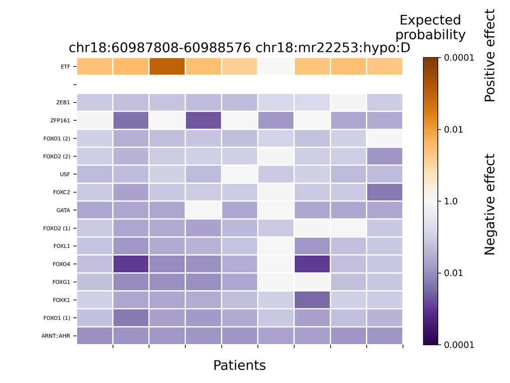

In addition, the other two blocks (block_0_18_60983893_60984144, block_1_18_60984827_60987028) are also identified as putative functional mutation blocks overlapping with DMRs in enhancer regions.

**CPU requirement**  
* MaxRSS: 440 MB  
* Running time: 5 hours and 3 minutes

## Python code

A bpb3 parameter configure file that can be directly loaded to the package:  
bpb3_config_mr_enhancers.py

```python
import os
import glob
from bpb3.script.script_high.other import common
import time

#this script is used to evaluate mutations in DNA methylation regions (MRs) that are overlapping with enhancers!!
#Here, most of bpb3 command line functions and parameter configures are shown in the same file

###########Setup main Path ################
#Project Output path
out_data_folder = os.path.abspath("../../final_demo_data/demo7_mr_enhancers/out")

#input data path
patient_data_folder = os.path.join(out_data_folder,'../', "patient_data")
normal_rnaseq_folder = os.path.join(out_data_folder,'../' ,"normal_gcb_counts")

#project name
project_name='demo7_mr_enhancers'

#Genome path
#genome data too large which needs to be stored in a separeted place from the demo data in github
genome_folder=os.path.abspath("../../final_demo_data/genome_data/hg19/")
genome_fasta_file= os.path.join(genome_folder, "human_g1k_v37_decoy.fasta")
gene_annotation_file= os.path.join(genome_folder, "gencode.v19.annotation.gtf")

#Start to make folder for clustered pwms, which is the only difference if input clustered PWMs for bayesPI-BAR !
#this part works when runCluster4PWM is True
#  Generate tempary pwms based on clustered and uncertain clustered PWMs ############
in_clustered_pwms_path=os.path.join(out_data_folder,'../')
in_clustered_pwms_folder_name='abc4pwm_quality_assessed_out_seed5'
in_uncertain_pwms_folder_name='abc4pwm_uncertain_pwms'
out_tmp_pwms_folder_name='tmp_pwm'
#end custer4PWM parameters

# folder with clustered PWM models for TF binding affinity
#pwm_folder=os.path.join(in_clustered_pwms_path,out_tmp_pwms_folder_name)
# folder with original PWM models for TF binding affinity
pwm_folder = os.path.join("../../final_demo_data/pwm")

# output data folders
foreground_folder = os.path.join(out_data_folder, "foreground")
background_folder = os.path.join(out_data_folder, "background")
background_pwm_folder = os.path.join(out_data_folder, "pwm_for_background")
mussd_result_folder = os.path.join(out_data_folder, "mussd_blocks")

#normal gene expression file name under folder normal_rnaseq_folder
normal_count_files_postprefix="*.only_counts.tsv"
gene_length_file = os.path.join(genome_folder, "gene_lengths.tsv")
#gene expression file name postprefix in folder patient_data_folder
donor_count_files_postprefix="D*/*_expression.tsv"

###########Setup Pipeline parameters #########
#1. Differential gene expression options
differentially_expressed_genes_file = os.path.join(out_data_folder, "differentially_expressed_genes.txt")
group1_str='tumor'
group2_str='normal'
#Export file path
group1_median_rpkm_file = os.path.join(out_data_folder, group1_str + "_median_patient_rpkm.tsv")
group2_median_rpkm_file = os.path.join(out_data_folder, group2_str +"_median_patient_rpkm.tsv")

# maximum Kolmogorov-Smirnov test P value to consider genes as differentially expressed
differential_expression_p = 0.05
# whether to do quantile normalization of RPKM values, True or False
differential_expression_quantile_normalization = True
# whether to do log transformation of RPKM values, True or False
differential_expression_log_transform = True
# whether to do z-score transformation of RPKM values, True or False
differential_expression_z_score_transform = False
# minimum fold change of [quantile normalized] RPKM to consider genes as differentially expressed. None to disable
differential_expression_min_fold_change = None
#export full expression data
isExportAll = True
#test_method 1 for T-test
test_method=1
#minimum median RPKM in each group
minimum_median_RPKM= 0   #1.0

# 2. Region of interest selection options
# number of base pairs to take upstream of TSS
#upstream_size = 1000
# number of base pairs to take downstream of TSS
#downstream_size = 1000
#Export file path
#regions_file = os.path.join(out_data_folder, "regions.bed")
#region selection function is disabled , a predefined region is used such as DMR overlapping to enhancers with a 5kb flank region in both side
regions_file='../../final_demo_data/demo7_mr_enhancers/in/dmr_intersect_enhancer_regions_chr18noChr_5kb_flank.tsv'


# 3. MuSSD options
# minimum number of patients in a hot mutation region
min_patients_in_block = 3
# minimum number of mutations in a hot mutation region
min_block_size = 3
# maximum distance between mutations in a hot mutation region
cluster_distance = 30
block_distance=500
# number of base pairs to add to the left and right side of a mutation block when extracting sequences
block_flank = 25

#4. P values for significant muation blocks use a big positive value >1 to switch off this filtering
p_value_for_significant_blocks=0.001
mussd_command_file=os.path.join(out_data_folder, 'run_mussd.sh')
pval_correction= True

#patient mutation file names under folder patient_data_folder
patient_mut_files_postprefix="DO*/icgc_mutations*.tsv"

#Export file path of significant mutation blocks
significant_blocks_file = os.path.join(out_data_folder, "significant_blocks.txt")

# 5. BayesPI-BAR options
# chemical potentials to use
chemical_potentials = "none -10 -13 -15 -18 -20"
# sequence shuffling iterations for dbA calculation
shuffling_iterations = 10000
#Parallel option path
parallel_options_file = os.path.abspath(os.path.join(os.path.dirname(__file__), "parallel_options.txt"))

# 6. Background model options
# max rank of a PWM file in the foreground results to include in the background model
max_ranking_for_background = 10
resampling_iterations = 10
gene_samples = 100
background_shuffling_iterations = 1000
background_command_file = os.path.join(out_data_folder, "make_background.sh")

# 7. mutation signature definition for generating background mutations, set to None to disable
mutation_signature_file = None  # "../../final_demo_data/background_data/signature_7.tsv"
# set to True to use tumor mutations from patients as background mutations, False otherwise.
# This and the mutation signature are mutually exclusive.
# In both are disabled, uniform mutations will be generated
tumor_mutations_as_background = True

# Results selection options for significant affinity changes
# P value for ranksum test in the output
affinity_change_p_value = 0.05
pval_correction4affinity= True
max_ranking_for_significant_blocks=30

#8. True or False parameters to run the bpb3, by either enable  or disable one of bpb3 steps

#step 1. differential expression analysis
runDiffExp= True

#step 2: region extraction, disable this function because we use predefined DMR overlapping enhancer regions
runRegionsFile=False


#step 3: mussd mutation block detection
runMussd= True

#step 4: highly mutated mutation block test
runHighMutBlocks= True

#step 5: do foreground bayespi-bar calculation
runBayesPiBAR= True

#step 6: do background bayespi-bar calcuation
runBackgroundModel= True

#step 7: do TF affinity change significance test
runBlockSignificance= True

#step 8: filter TF by gene expression level
filterTFbyGene= True

#step 9: plot heatmap for TFs with significaly changed binding affinity
isPlot=True

#step 10: remove temporary files in both foreground and background calculations
runRemoveTempFile=True

#option step: if the input PWMs are clustered PWMs from abc4pwm, then this option shall be True
runCluster4PWM=False
```